# Practical Machine Learning

Ramiro Asturias

August 28, 2016

# Project Description

Using devices such as Jawbone Up, Nike FuelBand, and Fitbit it is now possible to collect a large amount of data about personal activity relatively inexpensively. One thing that people regularly do is quantify how much of a particular activity they do, but they rarely quantify how well they do it. In this project, the goal will be to use data from accelerometers on the belt, forearm, arm, and dumbell of 6 participants. They were asked to perform barbell lifts correctly and incorrectly in 5 different ways.

# Project Objectives

The goal of the project is to predict the manner in which they did the exercise. The following report describes the model was built, how it is cross validation, the expected out of sample error is, and why the best fitting model was chosen.

## Report

### Loading Libraries

```r
library(abind)
library(arm)
library(caret)
library(kernlab)
library(klaR)
library(rattle)
library(randomForest)
```

```r
library(rpart)
library(knitr)
library(rpart.plot)
library(corrplot)
library(RColorBrewer)
```

## Data Description and Importing

Six young health participants were asked to perform one set of 10 repetitions of the Unilateral Dumbbell Biceps Curl in five different fashions:

Class A - > exactly according to the specification Class B - > throwing the elbows to the front Class C - > lifting the dumbbell only halfway Class D - > lowering the dumbbell only halfway Class E - > throwing the hips to the front .

Class A corresponds to the specified execution of the exercise, while the other 4 classes correspond to common mistakes.

The exercises were performed by six male participants aged between 20-28 years, with little weight lifting experience.

All participants could easily simulate the mistakes in a safe and controlled manner by using a relatively light dumbbell (1.25kg)

```r
# URL to get DataSets
UrlTrainData <- "http://d396qusza40orc.cloudfront.net/predmachlearn/pml-training.csv"
UrlTestData  <- "http://d396qusza40orc.cloudfront.net/predmachlearn/pml-testing.csv"

# Get DataSets
trainData <- read.csv(url(UrlTrainData))
testData  <- read.csv(url(UrlTestData))
```

## Prepare and Clean Data

```r
# Create Partition
inTrain  <- createDataPartition(trainData$classe, p=0.8, list=FALSE)
TrainSet <- trainData[inTrain, ]
TestSet  <- trainData[-inTrain, ]

#Remove Variables with Near Zero Variance
helper <- nearZeroVar(TrainSet)
TrainSet <- TrainSet[, -helper]
TestSet  <- TestSet[, -helper]

#Remove Variables that are mostly NA
helper   <- sapply(TrainSet, function(x) mean(is.na(x))) > 0.90
TrainSet <- TrainSet[, helper==FALSE]
TestSet  <- TestSet[, helper==FALSE]

#Remove identification variables (columns 1 to 7)
TrainSet <- TrainSet[, -(1:7)]
TestSet  <- TestSet[, -(1:7)]
```

After cleaning process the number of variables for the analysis is 52.

## Correlation Analisys

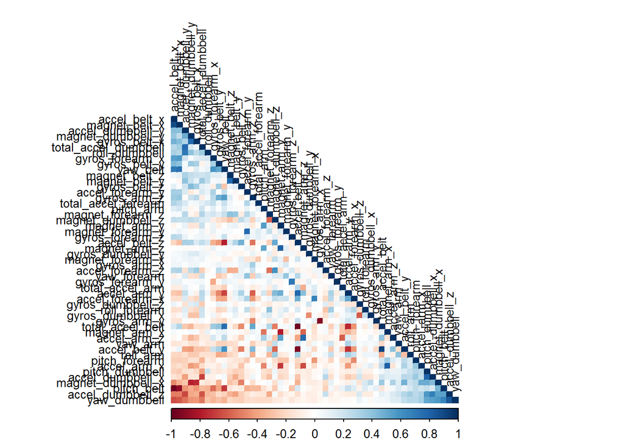

```r
# Detect Correlation
corMatrix <- cor(TrainSet[, -52])
corrplot(corMatrix,
         order = "FPC",
         method = "color",
         type = "lower",
         tl.col = "black",
         tl.cex = 0.8)
```

```r
corrAnal <- caret::findCorrelation(cor(TrainSet[, -52]), cutoff=0.8)
names(TrainSet)[corrAnal]
```

```
## [1] "accel_belt_z"     "accel_dumbbell_z" "accel_belt_y"
## [4] "accel_belt_x"     "pitch_belt"       "accel_dumbbell_x"
## [7] "accel_arm_x"      "magnet_arm_y"     "gyros_arm_x"
```

Variables above are highly correlated.

## CrossValidation

Models Test: Random forest Neural Net

```r
trainC <- trainControl(method = "cv",
                       verboseIter=TRUE)

#RandomForest
rf <- train(classe ~ ., data = TrainSet, method = "rf", trControl= trainC)
#Support Vector Machine
svm <- train(classe ~ ., data = TrainSet, method = "svmRadial", trControl= trainC)
#Neural Net
NN <- train(classe ~ ., data = TrainSet, method = "nnet", verbose=FALSE, trControl= trainC )
#Bayes Generalized Linear model
#bayesglm <- train(classe ~ ., data = TrainSet, method = "bayesglm", trControl= trainC)
#Logit Boosted model
#logitboost <- train(classe ~ ., data = TrainSet, method = "LogitBoost", trControl= trainC)
```

### Accuracy Results

```r
allModels <- c("Random Forest", "SVM","Neural Net")
Accuracy <- c(max(rf$results$Accuracy),
        max(svm$results$Accuracy),
        max(NN$results$Accuracy)
        )

Kappa <- c(max(rf$results$Kappa),
        max(svm$results$Kappa),
        max(NN$results$Kappa)
        )

results <- cbind(allModels,Accuracy,Kappa)

knitr::kable(results)
```

[output not shown]

## Prediction for the Test Set

```r
#Before using the actual Test we will predict with the test portion of the training SeT
rfPrediction <- predict(rf, TestSet)
confMatRandForest <- confusionMatrix(rfPrediction, TestSet$classe)
confMatRandForest
```

```
## Confusion Matrix and Statistics
##
##           Reference
## Prediction    A    B    C    D    E
##          A 1115    2    0    0    0
##          B    0  755    3    0    0
##          C    0    2  678    6    3
##          D    0    0    3  637    4
##          E    1    0    0    0  714
##
## Overall Statistics
##
##                Accuracy : 0.9939
##                  95% CI : (0.9909, 0.9961)
##     No Information Rate : 0.2845
##     P-Value [Acc > NIR] : < 2.2e-16
##
##                   Kappa : 0.9923
##  Mcnemar's Test P-Value : NA
##
## Statistics by Class:
##
##                      Class: A Class: B Class: C Class: D Class: E
## Sensitivity            0.9991   0.9947   0.9912   0.9907   0.9903
## Specificity            0.9993   0.9991   0.9966   0.9979   0.9997
## Pos Pred Value         0.9982   0.9960   0.9840   0.9891   0.9986
## Neg Pred Value         0.9996   0.9987   0.9981   0.9982   0.9978
## Prevalence             0.2845   0.1935   0.1744   0.1639   0.1838
## Detection Rate         0.2842   0.1925   0.1728   0.1624   0.1820
## Detection Prevalence   0.2847   0.1932   0.1756   0.1642   0.1823
## Balanced Accuracy      0.9992   0.9969   0.9939   0.9943   0.9950
```

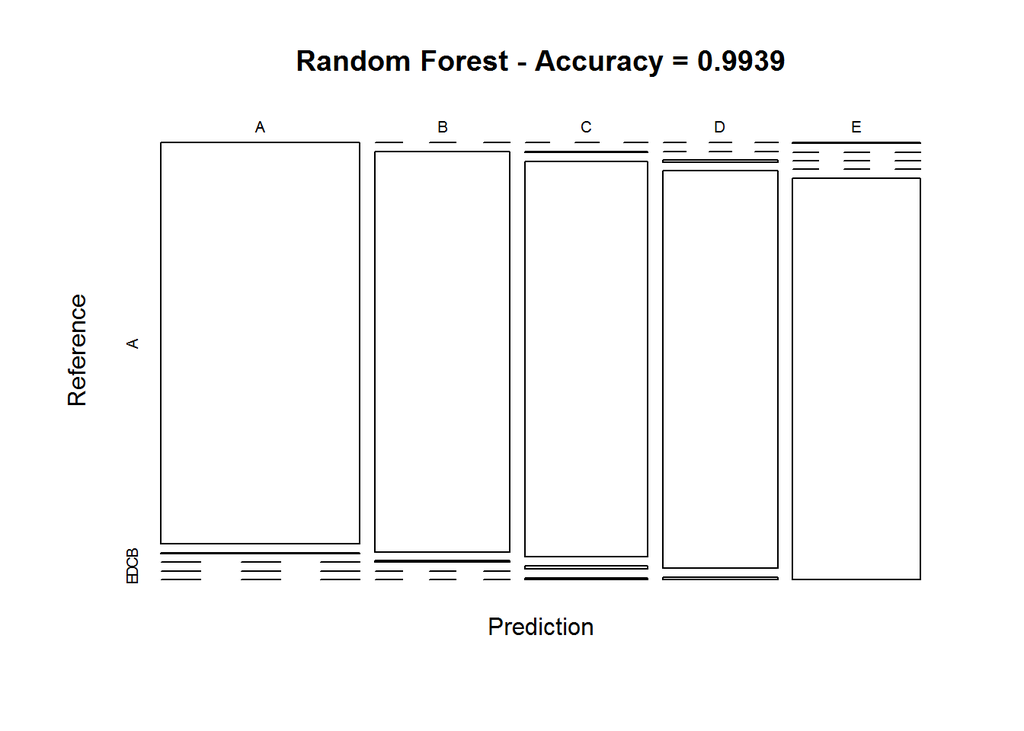

```r
# plot Results
plot(confMatRandForest$table, col = confMatRandForest$byClass,
     main = paste("Random Forest - Accuracy =",
                  round(confMatRandForest$overall['Accuracy'], 4)))
```

## Conclusions

The random forest model provides an outstanding accuracy in this case.